# Unsupervised Learning

## About Me

- Third year PhD student
- MSc in Data Science at Sapienza University of Rome
- Interest in NLP and SNA
- Reach me by email abbonato@unistra.fr
- Material on Github DSS-ML/Unsupervised

## Types of ML

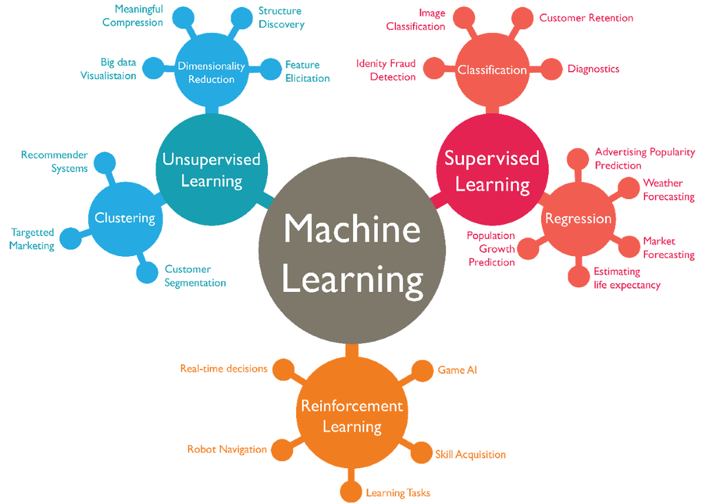

# Measure

# Dissimilarity

**It is a function $d_{i,j} = d(x_i,x_j)$ that associates each pair $ij$ with a numerical value to determine how 'distant' objects are from each other.**

- 1) Non negative $d_{i,j} ≥ 0$
- 2) Null $d_{ii} = 0$
- 3) Symmetry $d_{i,j} = d_{j,i}$
- 4) Triangle inequality $d_{i,j} ≤ d_{ik} + d_{jk}$

if $4_{th}$ condition is respected then we have a **distance**

# Similarity measures

- Euclidean $\rightarrow$ boss of straight line
- City Block, Manhattan $\rightarrow$ boss of the street
- Chebyshev $\rightarrow$ boss of trading stocks
- Cosine $\rightarrow$ rulez nlp
- Mahalanobis $\rightarrow$ when euclidean fails to give real distance between observation :/
- Jaccard $\rightarrow$ bff of cosine (dw about duplication)

# Unsupervised : Reduce Dimensionality

*the curse of dimensionality*

**what?**

- projects the original high-dimensional input data to a low-dimensional space

**why?**

- identify patterns and solve large-scale computationally expensive problems

**how?**

- filtering out the not-so-relevant features and keeping as much of the interesting ones as possible

**yes but how**

- linear & nonlinear

# Linear Projection

- linearly projecting data from a high-dimensioanl space to a low-dimensional space

```python
print('Let\'s load our favourite dataset\n')
iris = pd.read_csv('https://archive.ics.uci.edu/ml/machine-learning-databases/iris/iris.data',
                   names = ['sepal length','sepal width', 'petal length','petal width', 'target'])
print('Target',iris.target.unique().tolist())
print('Dimension of IRIS', iris.shape)
iris.head(3)
```

```
Let's load our favourite dataset

Target ['Iris-setosa', 'Iris-versicolor', 'Iris-virginica']
Dimension of IRIS (150, 5)
```

|  | sepal length | sepal width | petal length | petal width | target |
| --- | --- | --- | --- | --- | --- |
| 0 | 5.1 | 3.5 | 1.4 | 0.2 | Iris-setosa |
| 1 | 4.9 | 3.0 | 1.4 | 0.2 | Iris-setosa |
| 2 | 4.7 | 3.2 | 1.3 | 0.2 | Iris-setosa |

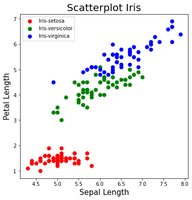

```python
fig = plt.figure(figsize = (6,6))
ax = fig.add_subplot(1,1,1)
ax.set_xlabel('Sepal Length', fontsize = 15)
ax.set_ylabel('Petal Length', fontsize = 15)
ax.set_title('Scatterplot Iris', fontsize = 20)

targets = ['Iris-setosa', 'Iris-versicolor', 'Iris-virginica']
colors = ['r', 'g', 'b']
for target, color in zip(targets,colors):
    indicesToKeep = iris['target'] == target
    ax.scatter(iris.loc[indicesToKeep, 'sepal length'],
               iris.loc[indicesToKeep, 'petal length'], c = color, s = 50)
ax.legend(targets)
fig.show()
```

# Principal Component Analysis

- identify which features out of the full set of features are most important in explaining the variability among the instances in the data
- each component is a linear combination of all the variables and is perpendicular to every other component
- J≤K
- lose some of the variance by moving to this low-dimensional space
- perform tasks like clustering more efficiently
- your data should be numeric and scaled!

# PCA

- it calculates the correlation and if this is very high among a subset of the features, PCA will attempt to combine the highly correlated features and represent this data with a smaller number of linearly uncorrelated features
- the algorithm keeps performing this correlation reduction, finding the directions of maximum variance in the original high dimensional data and projecting them into a smaller dimensional space
- these newly derived components are known as principal components

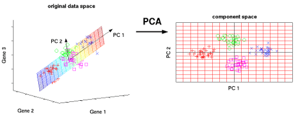

```python
from sklearn import decomposition
from sklearn.preprocessing import StandardScaler

X = StandardScaler().fit_transform(iris[['sepal length','sepal width','petal length','petal width']].values)
y = iris.target.values

pca = decomposition.PCA()
principalcomponents = pca.fit_transform(X)

df_2 = pd.DataFrame(principalcomponents)

principalcomponents_df = pd.concat([df_2,iris],axis=1).rename(columns = {0:'PC1',1:'PC2',2:'PC3',3:'PC4'})

principalcomponents_df.head(5)
```

|  | PC1 | PC2 | PC3 | PC4 | sepal length | sepal width | petal length | petal width | target |
| --- | --- | --- | --- | --- | --- | --- | --- | --- | --- |
| 0 | -2.264542 | 0.505704 | -0.121943 | -0.023073 | 5.1 | 3.5 | 1.4 | 0.2 | Iris-setosa |
| 1 | -2.086426 | -0.655405 | -0.227251 | -0.103208 | 4.9 | 3.0 | 1.4 | 0.2 | Iris-setosa |
| 2 | -2.367950 | -0.318477 | 0.051480 | -0.027825 | 4.7 | 3.2 | 1.3 | 0.2 | Iris-setosa |
| 3 | -2.304197 | -0.575368 | 0.098860 | 0.066311 | 4.6 | 3.1 | 1.5 | 0.2 | Iris-setosa |
| 4 | -2.388777 | 0.674767 | 0.021428 | 0.037397 | 5.0 | 3.6 | 1.4 | 0.2 | Iris-setosa |

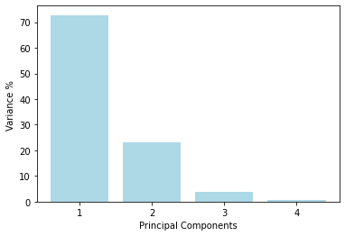

```python
PC = range(1, pca.n_components_+1)
plt.bar(PC,pca.explained_variance_ratio_*100, color = 'lightblue')
plt.xlabel('Principal Components')
plt.ylabel('Variance % ')
plt.xticks(PC)
plt.show()
```

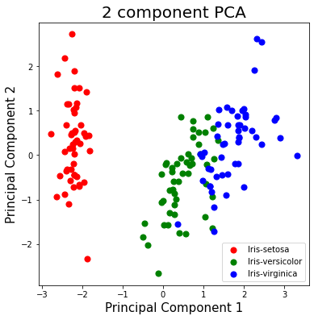

```python
fig = plt.figure(figsize = (6,6))
ax = fig.add_subplot(1,1,1)
ax.set_xlabel('Principal Component 1', fontsize = 15)
ax.set_ylabel('Principal Component 2', fontsize = 15)
ax.set_title('2 component PCA', fontsize = 20)

targets = ['Iris-setosa', 'Iris-versicolor', 'Iris-virginica']
colors = ['r', 'g', 'b']
for target, color in zip(targets,colors):
    indicesToKeep = principalcomponents_df['target'] == target
    ax.scatter(principalcomponents_df.loc[indicesToKeep, 'PC1']
               , principalcomponents_df.loc[indicesToKeep, 'PC2']
               , c = color
               , s = 50)
ax.legend(targets)
fig.show()
```

# Sparse PCA

- a version of PCA that retains some degree of sparsity controlled by a hyperparameter called $\alpha$
- the algorithm searches for linear combinations in just some of the input variables, reducing the original feature space to some degree but not as compactly as *normal* PCA

```python
#https://scikit-learn.org/stable/modules/generated/sklearn.decomposition.SparsePCA.html
from sklearn.decomposition import SparsePCA
sparsePCA = decomposition.SparsePCA(alpha=0.0001)

principalcomponents = sparsePCA.fit_transform(X)

df_2 = pd.DataFrame(principalcomponents)

principalcomponents_df = pd.concat([df_2,iris],axis=1).rename(columns = {0:'PC1',1:'PC2',2:'PC3',3:'PC4'})
principalcomponents_df.head(5)
```

|  | PC1 | PC2 | PC3 | PC4 | sepal length | sepal width | petal length | petal width | target |
| --- | --- | --- | --- | --- | --- | --- | --- | --- | --- |
| 0 | -2.236025 | 0.503858 | 0.118037 | -0.024440 | 5.1 | 3.5 | 1.4 | 0.2 | Iris-setosa |
| 1 | -2.070666 | -0.649831 | 0.226883 | -0.105946 | 4.9 | 3.0 | 1.4 | 0.2 | Iris-setosa |
| 2 | -2.346561 | -0.309866 | -0.051979 | -0.027556 | 4.7 | 3.2 | 1.3 | 0.2 | Iris-setosa |
| 3 | -2.290154 | -0.561204 | -0.100495 | 0.066258 | 4.6 | 3.1 | 1.5 | 0.2 | Iris-setosa |
| 4 | -2.358554 | 0.675069 | -0.025878 | 0.037404 | 5.0 | 3.6 | 1.4 | 0.2 | Iris-setosa |

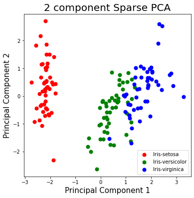

```python
fig = plt.figure(figsize = (6,6))
ax = fig.add_subplot(1,1,1)
ax.set_xlabel('Principal Component 1', fontsize = 15)
ax.set_ylabel('Principal Component 2', fontsize = 15)
ax.set_title('2 component Sparse PCA', fontsize = 20)

targets = ['Iris-setosa', 'Iris-versicolor', 'Iris-virginica']
colors = ['r', 'g', 'b']
for target, color in zip(targets,colors):
    indicesToKeep = principalcomponents_df['target'] == target
    ax.scatter(principalcomponents_df.loc[indicesToKeep, 'PC1']
               , principalcomponents_df.loc[indicesToKeep, 'PC2']
               , c = color
               , s = 50)
ax.legend(targets)
fig.show()
```